# Effects of Real Estate Attributes on Property Pricing, based on the 2016-2017 NYC Property Sales dataset.

## by Tatiana Tikhonova

## Investigation Overview

In this investigation, I would like to look at the property attributes that could be used to predict their prices, zooming in on the size, class, and location.

## Dataset Overview

The dataset consists of information regarding properties sold in New York City over a 12-month period from September 2016 to September 2017. It contains the location, address, type, sale price, and sale date of building units sold. A number of rows were removed due to them missing values that are crucial to our analysis.

# Apartment and Building Sales distribution by Borough

> First, it would be interesting to see how many sales took place in each of the city boroughs. Let's add some granularity and look at different property tax classes: does the Apartment sales distribution differ from the one for Buildings?

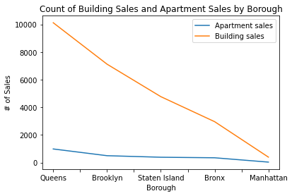

## Property Sales by Price and Borough

> Now let's check which ones get more expensive. We noticed that the majority of real estate deals were made in Queens, but does that mean that the overall sales value prevails in that borough as well? Take a look at the below slide and find out for yourself!

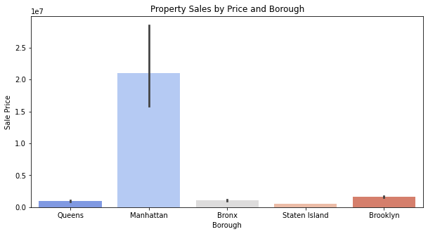

## Average Property Cost by Borough

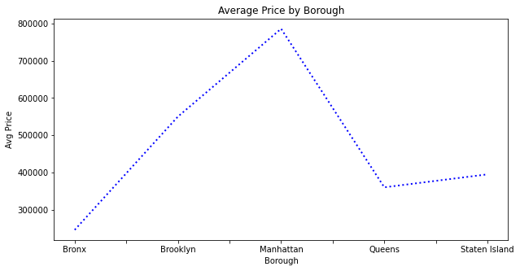

## Average Property Cost by Class

> Since we mentioned that all of these real estate deals include commercial deals, it would be eye opening to discover how much each type costs as compared to others. My guess is that office buildings rank the highest, what is yours? *(P.S. Take note of how Family Dwelling sales cost the lowest – something to remember when looking at the last slide.)*

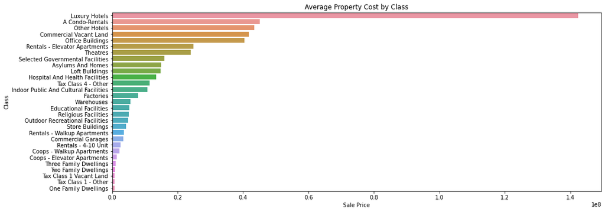

## Average Apartment Cost

> Let's separate apartments from buildings, and take a look at the former. Which type is on average more expensive, when looking at the 2016-2017 NYC sales?

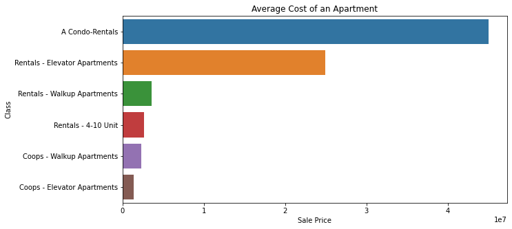

## Majority of Sales by Class

> Lastly, I'd like to show you what happens if we look at the total # of sales regardless of its price or location: which type of properties sold the most? Surprisingly, it's...

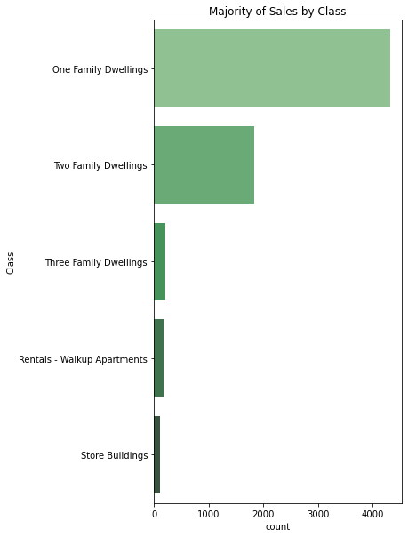

## The End

I hope you enjoyed this little slide show as much as I did. Thanks for checking it out!